# Beads community data

Author

Masatoshi Katabuchi

Published

November 2, 2026

```r
trait <- read_csv("data/dummy_trait.csv")
tree <- read.tree("data/dummy_tree.newick")
```

# 1 Dummy data

## 1.1 Habitat

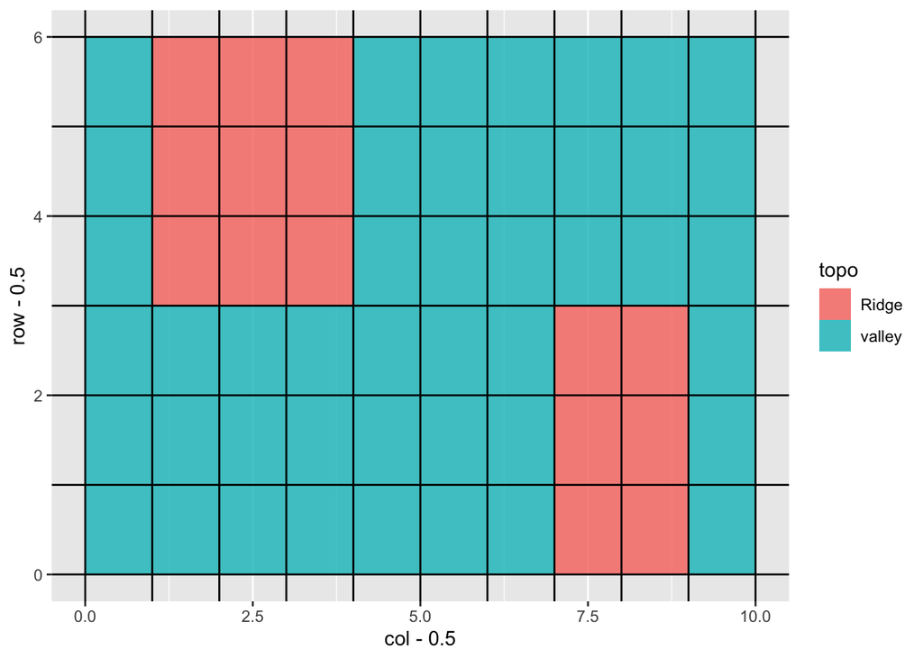

```r
x <- seq(1, 6)
y <- seq(1, 10)
z <- matrix(numeric(length(x) * length(y)), ncol = length(y))
z[1,8:9] <- z[2,8:9] <- z[3,8:9] <- 1
z[4,2:4] <- z[5,2:4] <- z[6,2:4] <- 1

z2 <- matrix(numeric(60), ncol = length(y))
z2[,1:5] <- 1

env <- tibble(env1 = as.numeric(z),
              env2 = as.numeric(z2)) %>%
  mutate(row = rep(1:6, 10)) %>%
  mutate(col = rep(1:10, each = 6)) %>%
  mutate(site = str_c("Site", 1:60)) %>%
  mutate(topo = ifelse(env1 == 1, "Ridge", "valley")) %>%
  mutate(type = ifelse(env2 == 1, "Rainforest", "Rubber"))

ggplot(env, aes(y = row - 0.5, x = col - 0.5, fill = topo)) +
    geom_raster(alpha = 0.8)  +
    geom_vline(xintercept = 0:10) +
    geom_hline(yintercept = 0:6)
```

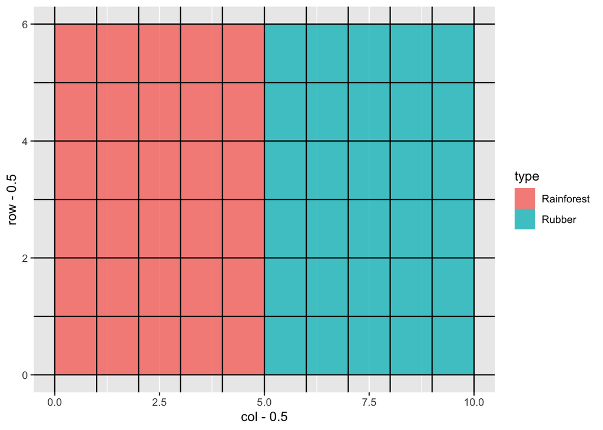

```r
ggplot(env, aes(y = row - 0.5, x = col - 0.5, fill = type)) +
    geom_raster(alpha = 0.8)  +
    geom_vline(xintercept = 0:10) +
    geom_hline(yintercept = 0:6)
```

```r
n_sp <- nrow(trait)

ts <- trait[,-1] %>% log %>% scale %>% as_tibble
```

## 1.2 Continuous environmental variables

- Soil N: percent dry mass, with a maximum of 0.4% at grid points.
- Moisture: a unitless index; larger values indicate higher moisture.
- Both variables are spatially autocorrelated. Moisture affects species abundance; soil N is not used in the abundance model.
- The 11 × 7 grid gives 77 corner measurements for 60 sampling quadrats. Each quadrat uses the mean of its four corners.

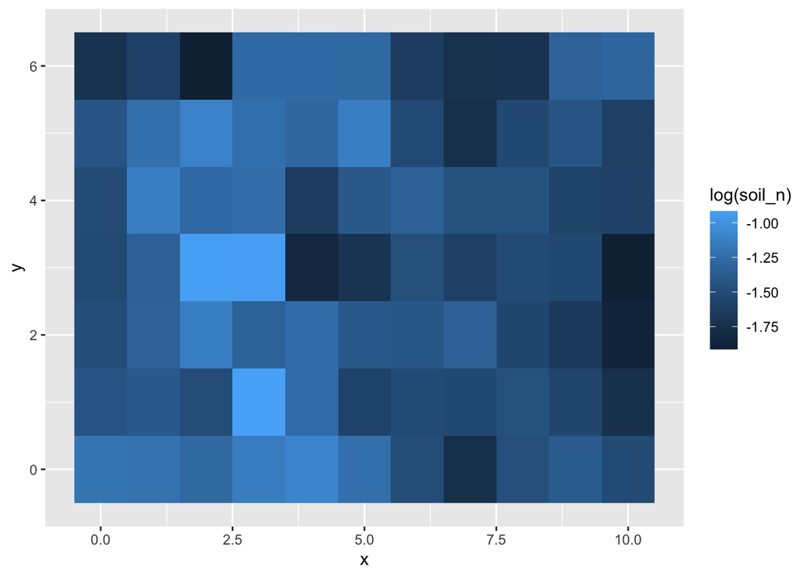

```r
generate_env <- function(seed = 123, model = c("ridge_negative", "ridge_positive", "random")) {
  model <- match.arg(model)
  set.seed(seed)
  x <- seq(1, 13)
  y <- seq(1, 9)
  z <- matrix(rnorm(length(x) * length(y)), ncol = length(y))
  if (model == "ridge_positive") {
    z[3:6, 6:9] <- 2
    z[9:11, 1:4] <- 2
  } else if (model == "ridge_negative") {
    z[3:6, 6:9] <- -5
    z[9:11, 1:4] <- -5
  }

  for (i in 2:(length(x)-1)) {
    for (j in 2:(length(y)-1)) {
      z[i, j] <-
        rnorm(1,
              mean(
                c(z[i - 1, j - 1],
                z[i - 1, j],
                z[i - 1, j + 1],
                z[i, j - 1],
                z[i, j + 1],
                z[i + 1, j - 1],
                z[i + 1, j],
                z[i + 1, j + 1])),
              0)
    }
  }
  z <- z[,-9]
  z <- z[,-1]
  z <- z[-13,]
  z <- z[-1,]

  x <- seq(1, 11)
  y <- seq(1, 7)
  x2 <- rep(x, length(y))
  y2 <- rep(y, each = length(x))
  # as.numeric(z)
  # as.numeric(t(z))

  dat <- tibble(x = x2 |> as.numeric(),
                y = y2,
                z = as.numeric(z) )
    # mutate(z = ifelse(x > 5, z + 1, z))

  dat2 <- dat %>%
    mutate(x = x - 1) %>%
    mutate(y = y - 1)
  dat2
}

moist <- generate_env(model = "ridge_negative")
nitro <- generate_env(model = "random")

nitro <- nitro |>
  mutate(soil_n = exp(z)) |>
  mutate(soil_n = soil_n / max(soil_n) * 0.4)

moist <- moist |>
  mutate(soil_moist = z)

dat2 <- nitro |>
  dplyr::select(-z) |>
  mutate(soil_moist = moist$soil_moist)

ggplot(dat2, aes(x = x, y = y, fill = soil_n |> log())) +
  geom_raster()
```

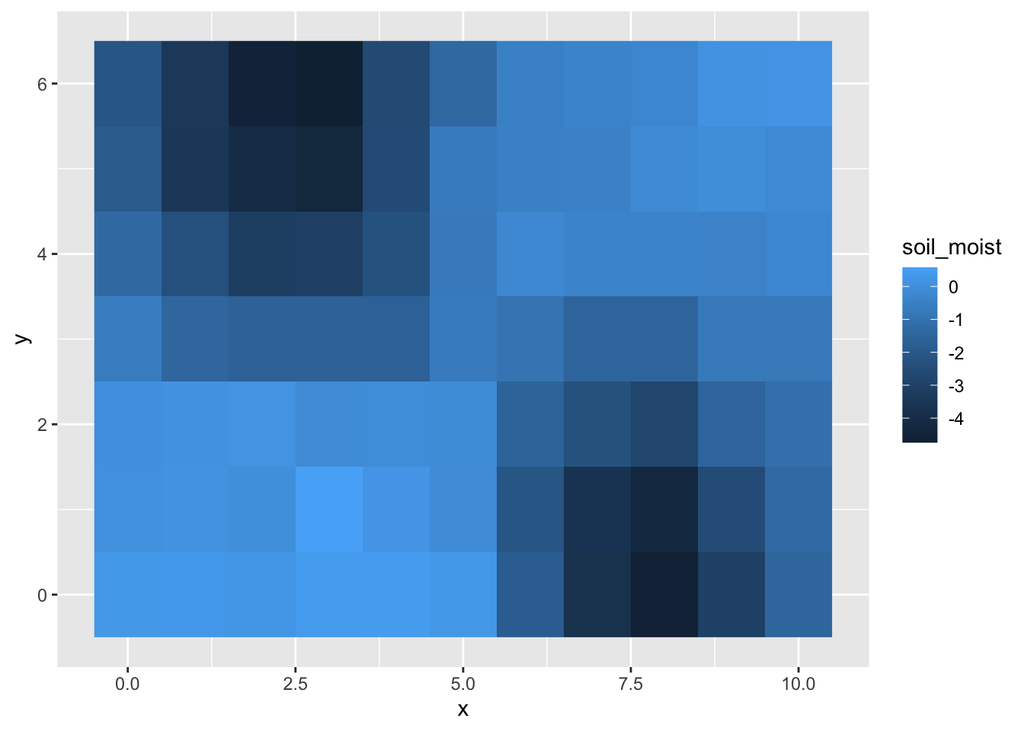

```r
ggplot(dat2, aes(x = x, y = y, fill = soil_moist)) +
  geom_raster()
```

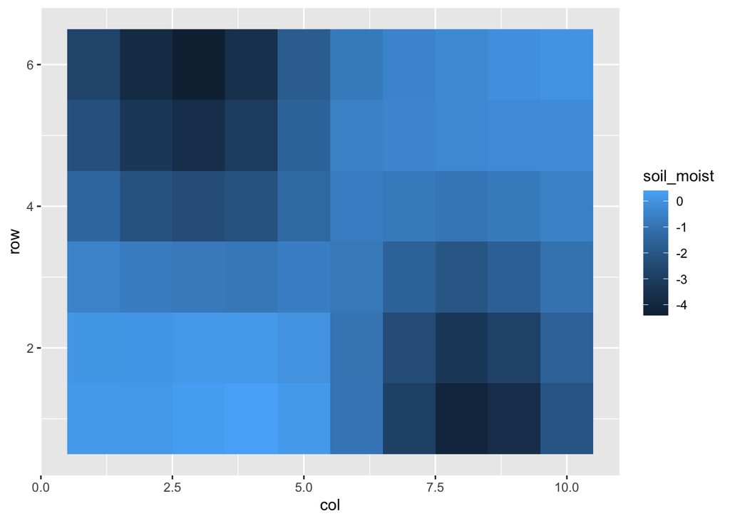

```r
tmp_fun <- function(data, env) {
  tmp <- NULL
  for (i in 0:9) {
    for (j in 0:5) {
       s1 <- data |>
          filter(x == i & y == j) |>
          pull({{env}})
       s2 <- data |>
          filter(x == (i + 1) & y == j) |>
          pull({{env}})
       s3 <- data |>
          filter(x == i  & y == (j + 1)) |>
          pull({{env}})
       s4 <- data |>
          filter(x == (i + 1) & y == (j + 1)) |>
          pull({{env}})
      tmp <- c(tmp, mean(c(s1, s2, s3, s4)))
    }
  }
  tmp
}

env3 <- env |>
  mutate(soil_n = tmp_fun(dat2, soil_n),
         soil_moist = tmp_fun(dat2, soil_moist))

ggplot(env3, aes(x = col, y = row, fill = soil_moist)) +
  geom_raster()
```

```r
dat2 |>
   dplyr::select(x, y, soil_n, soil_moist) |>
   round(3) |>
   write_csv("data/soil.csv")

env3 |>
  dplyr::select(site, row, col, topo, type, soil_n, soil_moist) |>
  write_csv("data/site_environment.csv")
```

## 1.3 Abundance

Abundance of species $i$ at site $j$:

$$A_{ij} \sim \mathrm{Poisson}(\lambda_{ij}), \qquad
\log \lambda_{ij} = \beta_{0i} + \beta_{1i} R_j + \beta_{2i} F_j
+ \beta_{3i} R_j F_j + \beta_{4i} M_j.$$

Here $R_j = 1$ for ridge, $F_j = 1$ for rainforest, and $M_j$ is the four-corner mean moisture index. Let $L_i$, $W_i$, and $S_i$ denote standardized log LMA, log wood density, and log seed mass, respectively:

$$\begin{aligned}
\beta_{0i} &= 5 + 0.5 C_i + \epsilon_{0i}, \\
\beta_{1i} &= -2 + 1.2 L_i + 0.3 W_i + \epsilon_{1i}, \\
\beta_{2i} &= -1 + 0.8 S_i + \epsilon_{2i}, \\
\beta_{3i} &= 0.3 L_i + \epsilon_{3i}, \\
\beta_{4i} &= -0.1 L_i + \epsilon_{4i}, \qquad
\epsilon_{mi} \sim N(0, 0.2^2)\ (m=0,\ldots,3),\quad \epsilon_{4i} \sim N(0, 0.05^2).
\end{aligned}$$

The abundance model is tuned for scattering beads by eye: most species are spread across the larger valley area, while a small number retain a ridge preference. Weaker moisture and ridge × forest effects prevent very dry corners from becoming extreme abundance hotspots. The maps show relative spatial patterns; the simulated counts are not literal bead placement instructions.

Species baseline abundance is weakly calibrated using `data/actual_abund.csv`. For species whose names match exactly, $C_i$ is standardized $\log(n_i+1)$, computed over the matched species and clipped to $[-1.5, 1.5]$. For species absent from that file, $C_i=0$; absence from the file is not treated as an observed zero. This multiplies expected abundance by approximately 0.47–2.12 at every site for a given species, preserving its relative expected spatial distribution. The generated communities remain simulations rather than reconstructions of the observed community.

High richness in valleys is intentional. Presence/absence metrics can be identical between sites even when abundances and community-weighted means differ.

```r
actual_abund <- read_csv("data/actual_abund.csv", show_col_types = FALSE)
stopifnot(all(c("latin", "n") %in% names(actual_abund)),
          !anyNA(actual_abund$latin), !anyDuplicated(actual_abund$latin),
          all(is.finite(actual_abund$n)), all(actual_abund$n >= 0))

actual_n <- actual_abund$n[match(trait$sp, actual_abund$latin)]
matched <- !is.na(actual_n)
abundance_z <- rep(0, n_sp)
# Unlisted species retain a neutral baseline. No random draws are added here.
if (sum(matched) >= 2L && sd(log1p(actual_n[matched])) > 0) {
  abundance_z[matched] <- as.numeric(scale(log1p(actual_n[matched])))
}
abundance_offset <- 0.5 * pmax(-1.5, pmin(1.5, abundance_z))

tibble(sp = trait$sp, actual_n,
       baseline_multiplier = exp(abundance_offset)) |>
  write_csv("data/abundance_adjustment.csv")

set.seed(456) # Independent of environmental generation and plotting.
beta0 <- rnorm(n_sp, 5, 0.2) + abundance_offset

beta1 <- rnorm(n_sp,
               mean = -2 + 1.2 * ts$lma + 0.3 * ts$wd,
               sd = 0.2)

beta2 <- rnorm(n_sp, -1 + 0.8 * ts$sm, 0.2)

beta3 <- rnorm(n_sp,
               mean = 0.3 * ts$lma,
               sd = 0.2)

beta4 <- rnorm(n_sp,
               mean = -0.1 * ts$lma,
               sd = 0.05)

beta <- cbind(beta0, beta1, beta2, beta3, beta4)

env2 <- tibble(intercept  = 1,
               env1 = env$env1,
               env2 = env$env2,
               interaction = env$env2 * env$env1,
               moist = env3$soil_moist)

env2
```

```
# A tibble: 60 × 5
   intercept  env1  env2 interaction   moist
       <dbl> <dbl> <dbl>       <dbl>   <dbl>
 1         1     0     1           0  0.205
 2         1     0     1           0  0.0879
 3         1     0     1           0 -0.483
 4         1     0     1           0 -1.44
 5         1     0     1           0 -2.25
 6         1     0     1           0 -2.73
 7         1     0     1           0  0.170
 8         1     0     1           0  0.106
 9         1     0     1           0 -0.693
10         1     1     1           1 -2.14
# ℹ 50 more rows
```

```r
summary(ts)
```

```
      lma                 ll              a_mass            r_mass
 Min.   :-2.18676   Min.   :-2.2049   Min.   :-2.7228   Min.   :-2.15195
 1st Qu.:-0.77355   1st Qu.:-0.6740   1st Qu.:-0.5136   1st Qu.:-0.79937
 Median :-0.04754   Median : 0.1400   Median : 0.0949   Median : 0.08833
 Mean   : 0.00000   Mean   : 0.0000   Mean   : 0.0000   Mean   : 0.00000
 3rd Qu.: 0.64007   3rd Qu.: 0.5798   3rd Qu.: 0.6548   3rd Qu.: 0.75962
 Max.   : 2.70288   Max.   : 2.5399   Max.   : 2.8365   Max.   : 2.26910
     n_mass            p_mass               wd                 sm
 Min.   :-2.1422   Min.   :-2.49885   Min.   :-2.45326   Min.   :-2.3815
 1st Qu.:-0.7750   1st Qu.:-0.74866   1st Qu.:-0.65928   1st Qu.:-0.7725
 Median : 0.1462   Median :-0.07159   Median : 0.03507   Median : 0.1505
 Mean   : 0.0000   Mean   : 0.00000   Mean   : 0.00000   Mean   : 0.0000
 3rd Qu.: 0.7016   3rd Qu.: 0.82344   3rd Qu.: 0.71158   3rd Qu.: 0.8935
 Max.   : 2.1241   Max.   : 2.02836   Max.   : 1.99403   Max.   : 1.6386
```

```r
mu <- beta %*% t(env2)
ab <- matrix(0, nrow = nrow(mu), ncol = ncol(mu),
             dimnames = list(trait$sp, env$site))
for (i in 1:nrow(mu)) {
  for (j in 1:ncol(mu)) {
    ab[i, j] <- rpois(1, exp(mu[i, j]))
  }
}

# Export all species-site combinations, including zero counts.
as.data.frame(as.table(ab), responseName = "abund") |>
  as_tibble() |>
  transmute(Site = as.character(Var2), Species = as.character(Var1), abund) |>
  write_csv("data/samp.csv")
```

# 2 Species abundance

```r
# Function to plot abundance for top/bottom species based on a specific trait
plot_abundance <- function(env, ab, species_list, title_list) {
  for (i in seq_along(species_list)) {
    p <- env %>%
      mutate(abund = ab[species_list[i], ]) %>%
      ggplot(aes(x = col - 0.5, y = row - 0.5, fill = abund)) +
      ggtitle(title_list[i]) +
      geom_raster() +
      geom_vline(xintercept = 0:10) +
      geom_hline(yintercept = 0:6)
    print(p)
  }
}

# Set rownames for abundance matrix `ab`
rownames(ab) <- trait$sp
```

## 2.1 Plot Top 5 LMA

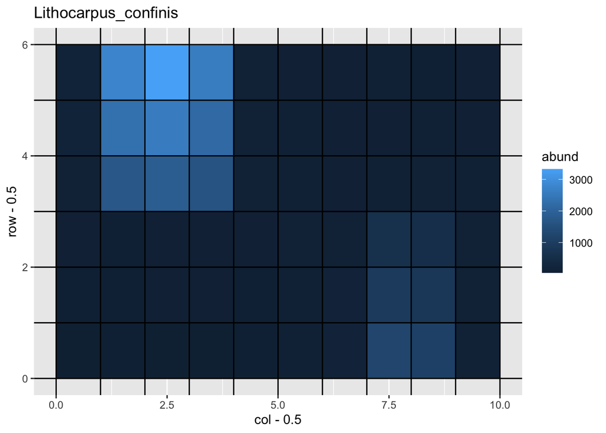

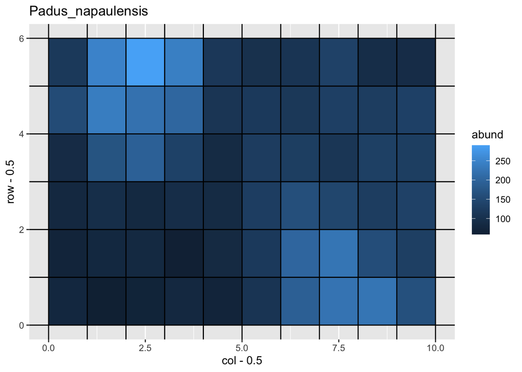

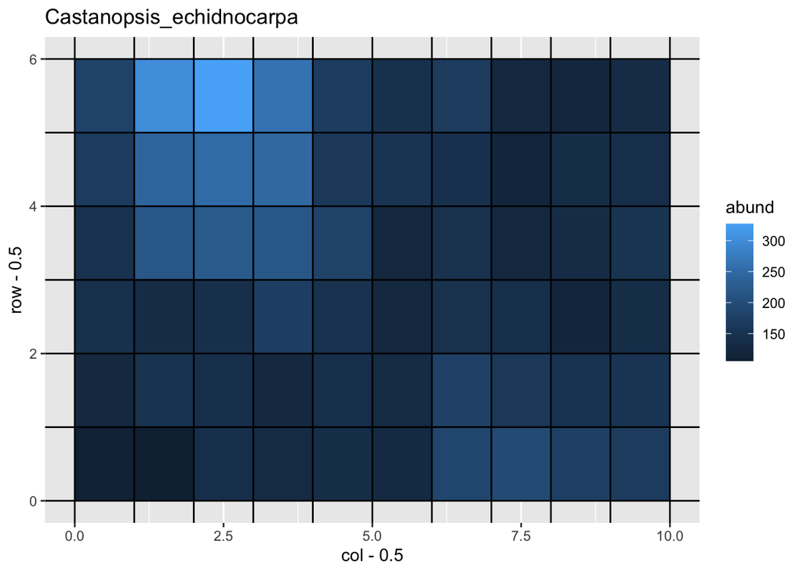

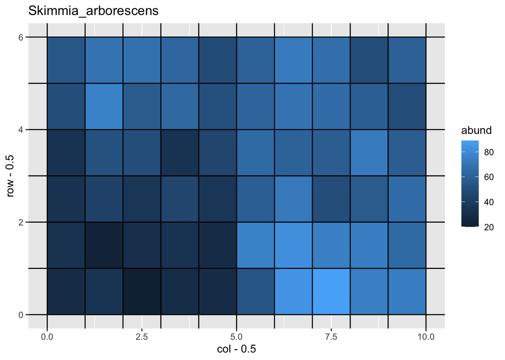

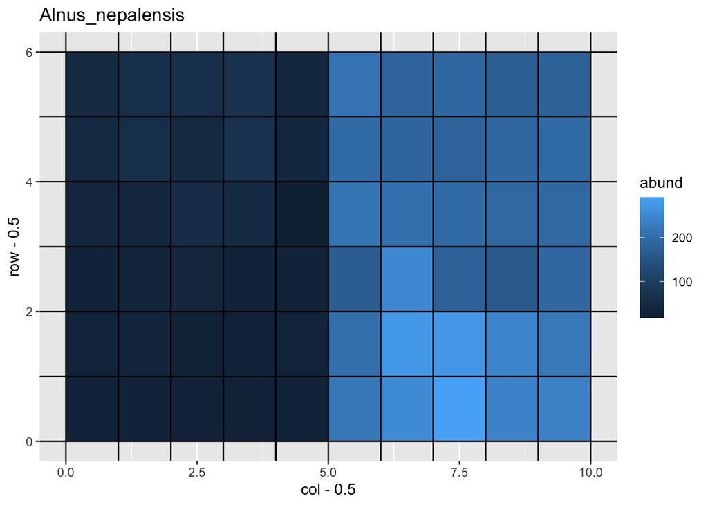

```r
top_sp_lma <- trait %>%
  arrange(-lma) %>%
  slice(1:5) %>%
  pull(sp)
plot_abundance(env, ab, top_sp_lma, top_sp_lma)
```

## 2.2 Plot Lowest 5 LMA

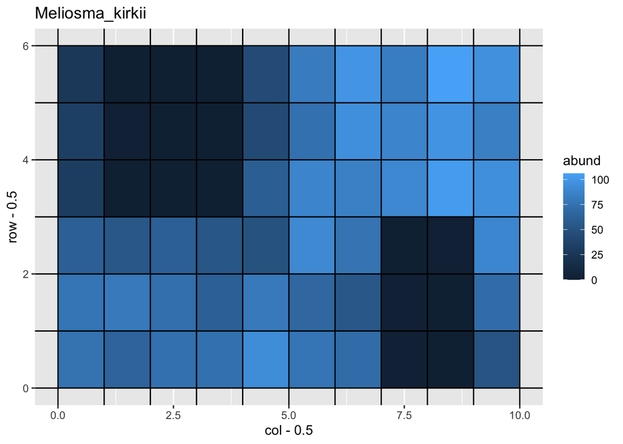

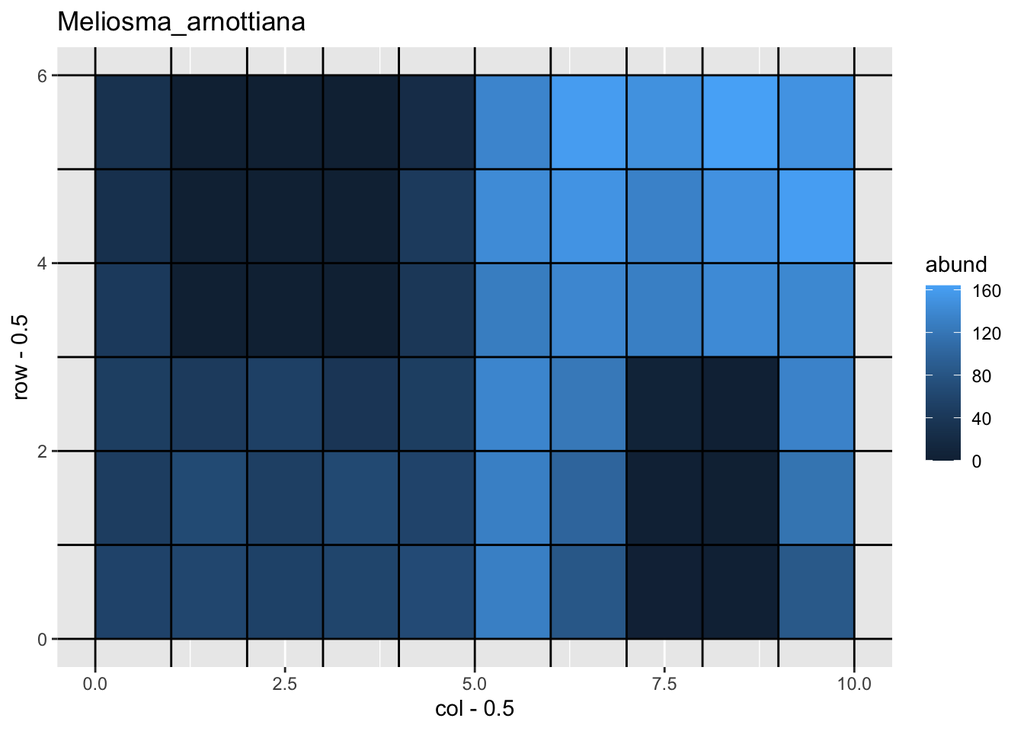

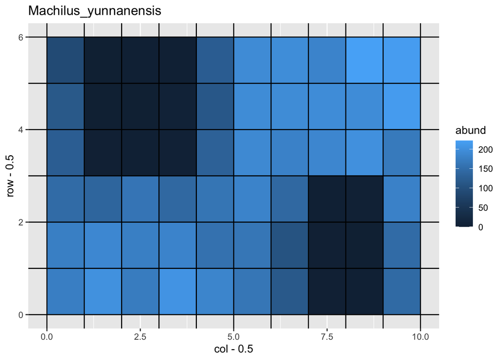

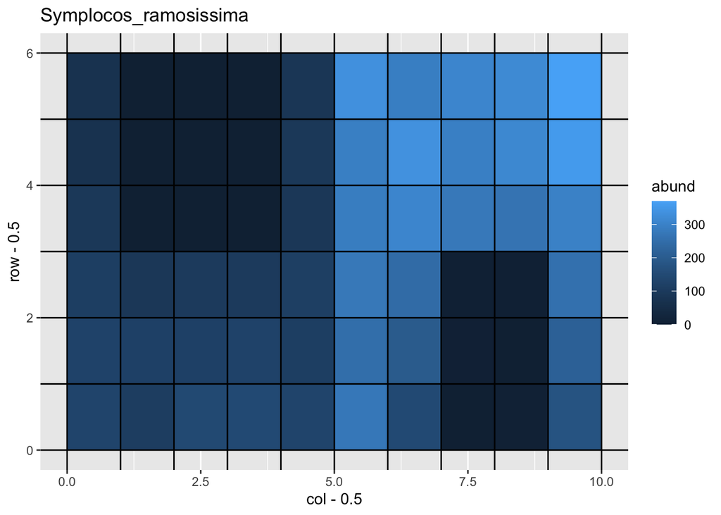

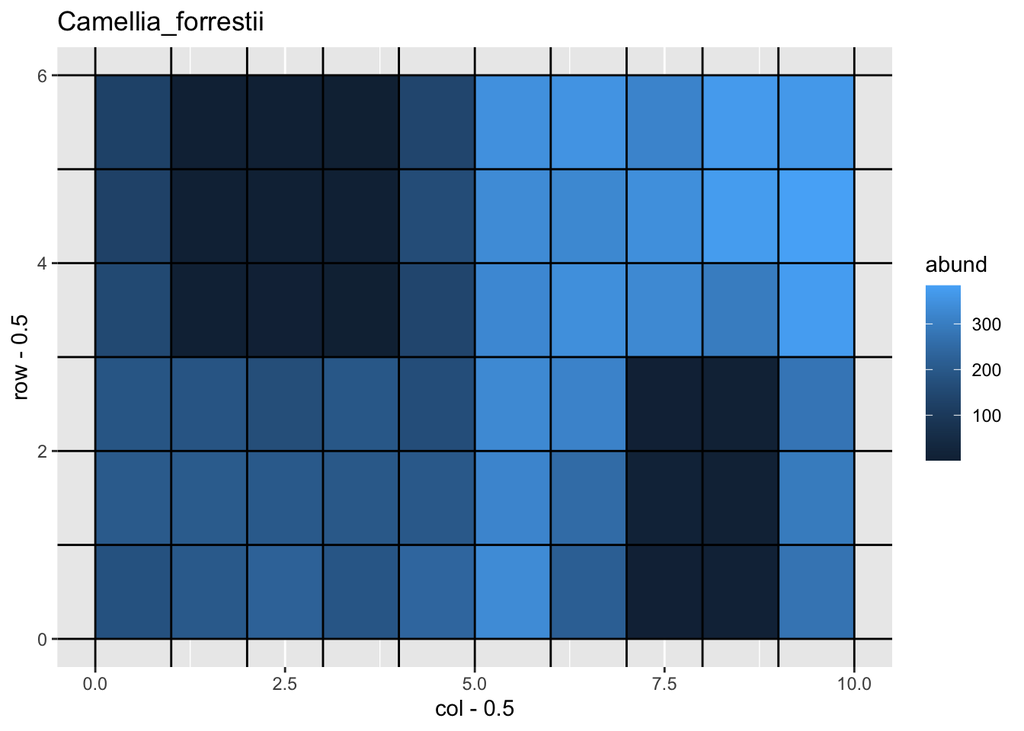

```r
low_sp_lma <- trait %>%
  arrange(lma) %>%
  slice(1:5) %>%
  pull(sp)
plot_abundance(env, ab, low_sp_lma, low_sp_lma)
```

## 2.3 Plot Top 5 Seed Mass

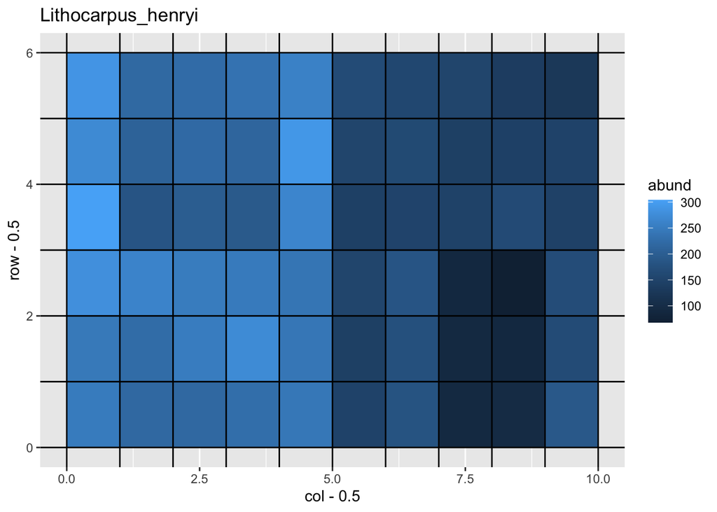

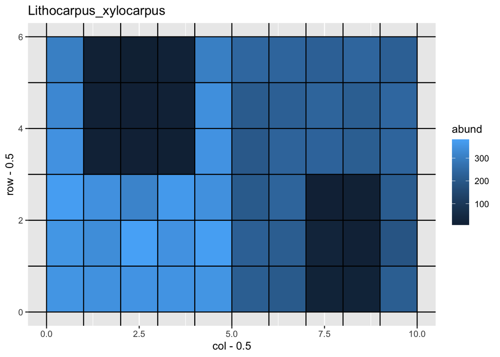

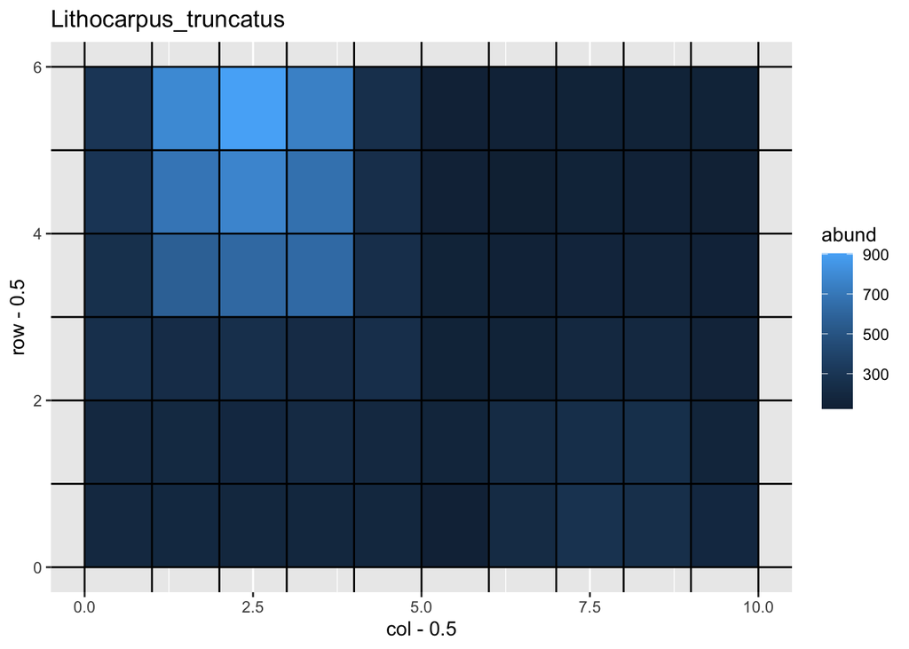

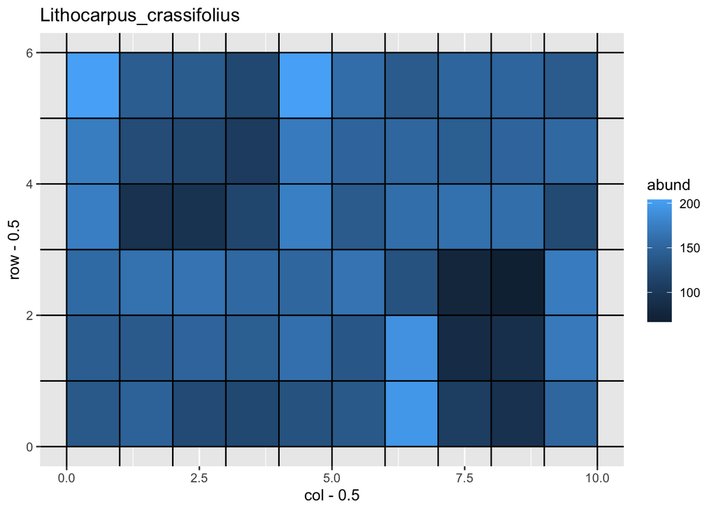

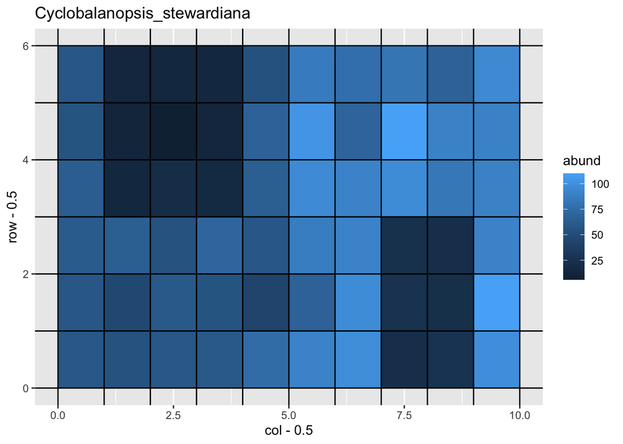

```r
top_sp_sm <- trait %>%
  arrange(-sm) %>%
  slice(1:5) %>%
  pull(sp)
plot_abundance(env, ab, top_sp_sm, top_sp_sm)
```

## 2.4 Plot Lowest 5 Seed Mass

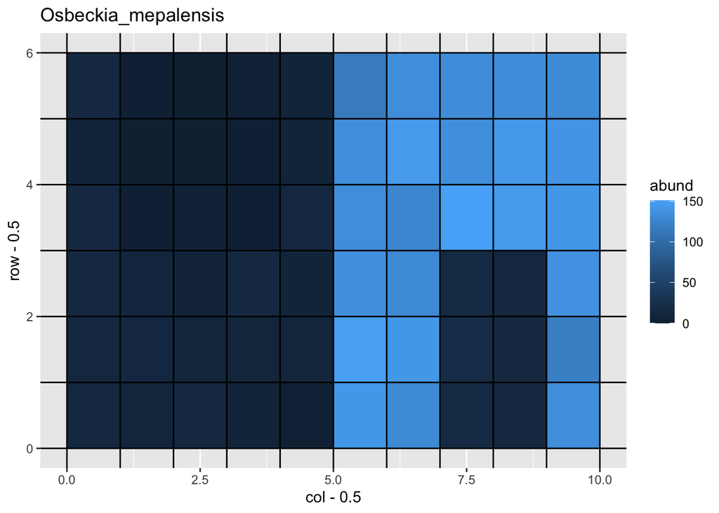

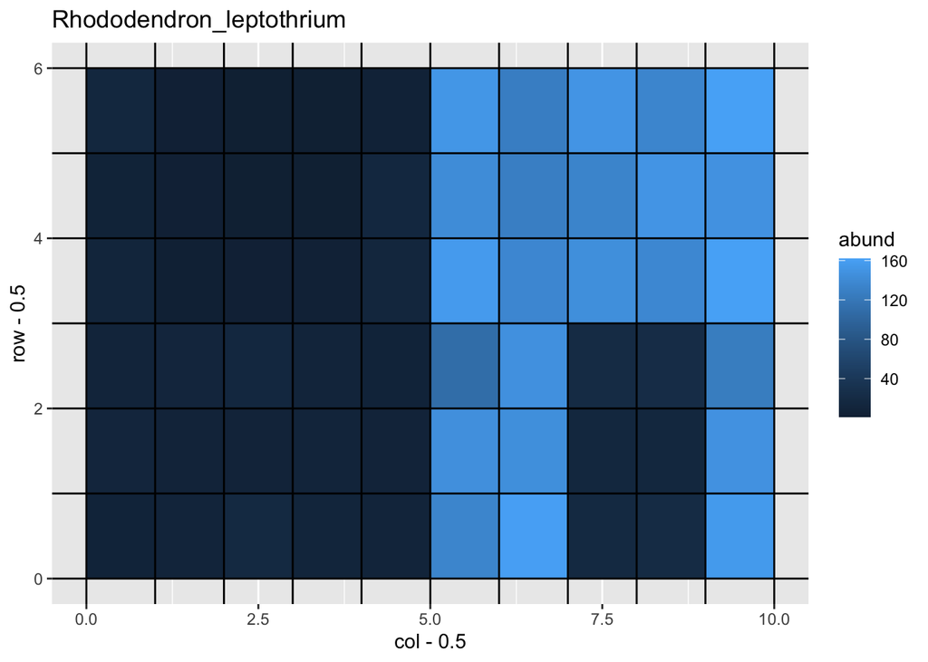

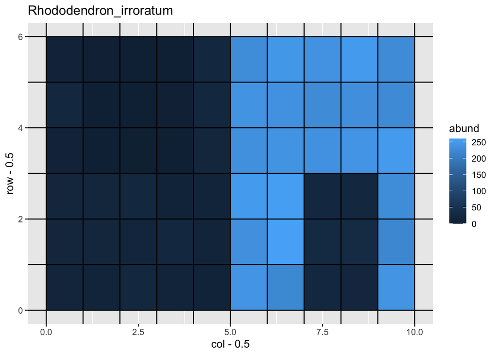

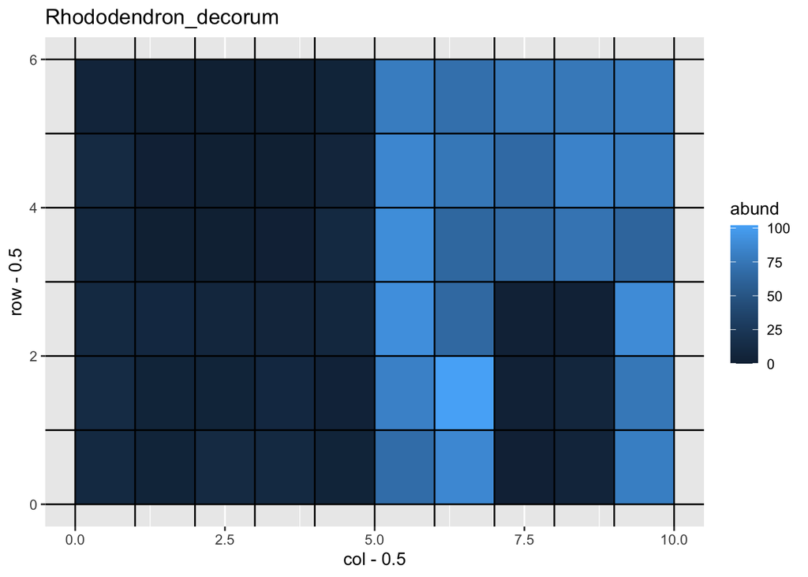

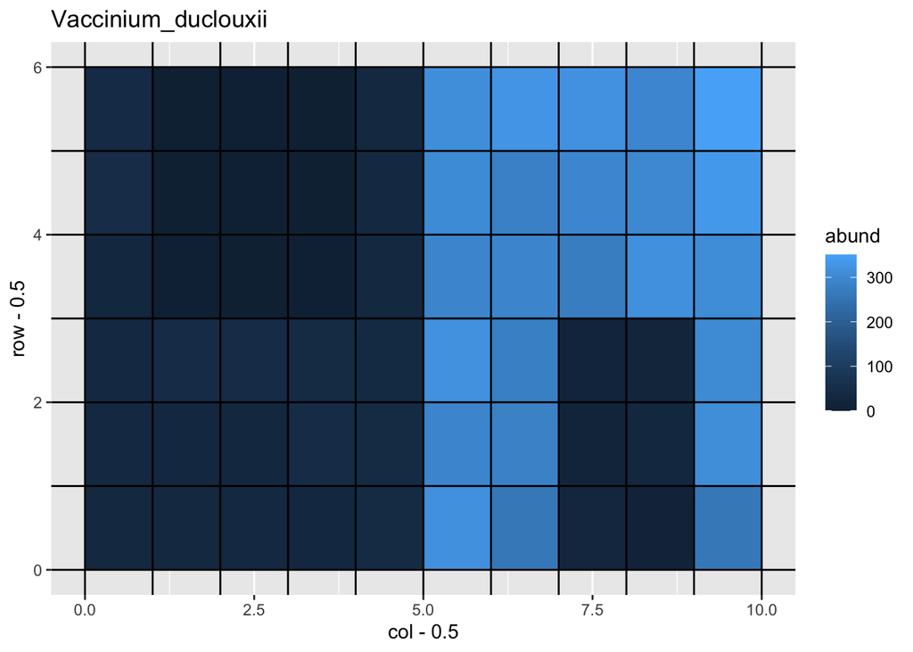

```r
low_sp_sm <- trait %>%
  arrange(sm) %>%
  slice(1:5) %>%
  pull(sp)

plot_abundance(env, ab, low_sp_sm, low_sp_sm)
```

# 3 Species list

## 3.1 Focal species with extreme LMA or seed mass

These are selected by trait values, not by their realized abundance.

```r
focal_sp <- c(top_sp_lma, low_sp_lma, top_sp_sm, low_sp_sm) |>
  unique() |>
  sort()
focal_sp
```

```
 [1] "Alnus_nepalensis"            "Camellia_forrestii"
 [3] "Castanopsis_echidnocarpa"    "Cyclobalanopsis_stewardiana"
 [5] "Lithocarpus_confinis"        "Lithocarpus_crassifolius"
 [7] "Lithocarpus_henryi"          "Lithocarpus_truncatus"
 [9] "Lithocarpus_xylocarpus"      "Machilus_yunnanensis"
[11] "Meliosma_arnottiana"         "Meliosma_kirkii"
[13] "Osbeckia_mepalensis"         "Padus_napaulensis"
[15] "Rhododendron_decorum"        "Rhododendron_irroratum"
[17] "Rhododendron_leptothrium"    "Skimmia_arborescens"
[19] "Symplocos_ramosissima"       "Vaccinium_duclouxii"
```